# Customer At Risk Model

### Training data construction

- Independent variables date range: up to Dec 2018
- Dependent variable date range: Feb-Arp 2019
- We intentionally leave a one month gap between the two so that
  1. We can have all the data needed to make predictions
  2. We can have time to think about how to execute on the predictions.

Pull R12 historical sales by product segmentation. Calculate % of sales by segmentation. This has to be done locally.

```r
myconn <- odbcConnect("Teradata LDAP")
prod_seg <- sqlQuery(myconn, "select * from prd_dwh_view_lmt.Material_Product_Segmentation_view")
prod_seg <- filter(prod_seg, is.na(PROD_SEG) != T)
prod_sales <- sqlQuery(myconn, "SELECT b.BUS_LOCATION_ID, SI.fiscper, p.cat_ID,
                  SUM(SI.SUBTOTAL_2) as sales
                  FROM PRD_DWH_VIEW_LMT.Mdm_Account_Org_Summary_view b RIGHT JOIN
                  PRD_DWH_VIEW_LMT.Sales_Invoice_V SI ON SI.SOLD_TO=b.SAP_ACCT_ID
                  LEFT JOIN PRD_DWH_VIEW_LMT.PROD_HIER_V p ON SI.prod_hier = p.prod_hier
                  WHERE SI.ZZCOMFLG = 'Y' AND
                  SI.COMP_CODE = '0300' AND
                  SI.ZPOSTSTAT = 'C' AND
                  SI.FISCPER  BETWEEN  2018001  AND  2018012 AND
                  SI.ACCNT_ASGN IN ('01','20')
                  GROUP BY 1, 2, 3")
prod_seg_sales <- inner_join(prod_sales, prod_seg, by = c("cat_id" = "CAT_ID")) %>%
  group_by(BUS_LOCATION_ID, PROD_SEG) %>%
  summarise(sales = sum(sales, na.rm = T)) %>%
  group_by(BUS_LOCATION_ID) %>%
  mutate(per=paste0(round(sales/sum(sales)*100, 2), "%")) %>%
  ungroup()
View(prod_seg_sales)
odbcClose(myconn)
```

Reshape the dataset. Recode missing values

```r
sales <- prod_seg_sales %>%
  select(-per) %>%
  spread(PROD_SEG, sales) %>%
  rename_at(vars(2:ncol(sales)), ~ paste0(., "_sales"))

pct <- prod_seg_sales %>%
  select(-sales) %>%
  spread(PROD_SEG, per) %>%
  rename_at(vars(2:ncol(per)), ~ paste0(., "_pct"))

prod_seg_sales_reshaped <- full_join(sales, pct) %>%
  replace(is.na(.), 0)
write.csv(prod_seg_sales_reshaped, "prod_seg_sales.csv", row.names = F)
```

Import prod seg sales.

```r
prod_seg_sales <- fread("prod_seg_sales.csv", data.table = F)
str(prod_seg_sales)
```

Import NEW model file as of April 2019. Exclude off-account locations. This is our dependent variable.

```r
sales_3M <- fread('/hadoop/grainger/data_science/inputFiles/modelFiles/201904_Apr_merged_model_file_NEW.csv', data.table = F)
sales_3M <- sales_3M %>%
  filter(ACCOUNT %in% c(111111118, 222222226, 244444444) == F) %>%
  mutate(Trans_3M = TRANS03 + TRANS02 + TRANS01) %>%
  select(ACCOUNT, Trans_3M)
str(sales_3M)
```

Import new model file as of Dec 2018. Exclude off-account locations. This will be for our independent variables.

```r
model_file <- fread('/hadoop/grainger/data_science/inputFiles/modelFiles/201812_Dec_merged_model_file_NEW.csv', data.table = F)
model_file <- filter(model_file, ACCOUNT %in% c(111111118, 222222226, 244444444) == F)
```

merge the two files using account number first.

- it’s not a good idea to aggregate the two files to BUS LOC level and then merge the two files because bus location ID got re-stated often.

```r
merge <- left_join(model_file, sales_3M, by = "ACCOUNT")
rm(model_file)
rm(sales_3M)
```

Aggregate data from account to location level

```r
loc_aggr_sum <- merge %>%
  group_by(BUS_LOC_ID) %>%
  summarise_at(vars(BRNCH_S12X:INVLNS24, TRANS36:WA_S12X, LINES12X:WLDGN24X, Trans_3M), sum, na.rm = T)
### had to split the following commands because otherwise it was taking long.
merge <- merge %>% arrange(desc(-BUS_LOC_ID), desc(SALES12X), desc(mrospend))

loc_aggr_first <- merge %>%
  group_by(BUS_LOC_ID) %>%
  summarise_at(vars(CSG, EMPHERE, DUNSYRST:dunspop, indseg1, Corp_Maj_Flag, market_segment), first)

# loc_aggr_first <- model_file %>%
#   arrange(desc(SALES12X)) %>%
#   group_by(BUS_LOC_ID) %>%
#   summarise_at(vars(CSG, indseg1, Corp_Maj_Flag, market_segment), first)

loc_aggr_min <- merge %>%
  group_by(BUS_LOC_ID) %>%
  summarise_at(vars(RECENCY, DISTANCE, mro_decile), min)

loc_aggr_max <- merge %>%
  group_by(BUS_LOC_ID) %>%
  summarise_at(vars(TENURE, mrospend, INVSOLFLG, multisite, CONTRACT_FLAG), max)


loc_aggr <- full_join(loc_aggr_sum, loc_aggr_first) %>%
  full_join(loc_aggr_min) %>%
  full_join(loc_aggr_max)

rm(loc_aggr_first)
rm(loc_aggr_sum)
rm(loc_aggr_min)
rm(loc_aggr_max)
loc_aggr <- ungroup(loc_aggr)
str(loc_aggr)
rm(merge)
```

Merge location aggr with prod seg sales data

```r
loc_aggr <- left_join(loc_aggr, prod_seg_sales, by = c("BUS_LOC_ID" = "BUS_LOCATION_ID")) %>%
  filter(BUS_LOC_ID != 0)
summary(loc_aggr$Trans_3M)
loc_aggr <- loc_aggr %>%
  mutate(Trans_3M = ifelse(is.na(Trans_3M), 0, Trans_3M))
rm(prod_seg_sales)
```

### Feature engineering

- convert data types
- create pre period transaction variables, 3M, 6M, 12M, etc.
- create % of sales by traditional prod segmentation.
- standardize the variable names by removing spaces.
- Add % of sales by channel
- One-hot encoding
- Create dependent variable - lapse flag

```r
loc_aggr <- loc_aggr %>%
  mutate(BUS_LOC_ID = as.character(BUS_LOC_ID),
         mro_decile = as.factor(mro_decile),
         Corp_Maj_Flag = as.factor(Corp_Maj_Flag),
         multisite = as.factor(multisite),
         indseg1 = as.factor(indseg1),
         CONTRACT_FLAG = as.factor(CONTRACT_FLAG),
         coverage = ifelse(substr(CSG, 1, 2) %in% seq(72, 78), "ISA",
                           ifelse(substr(CSG, 1, 2) %in% c(84, 88), "AM",
                                  ifelse(substr(CSG, 1, 2) == 83, "FAR",
                                         ifelse(substr(CSG, 1, 2) == 89, "Gov ARM",
                                                       "Uncovered")))),
         coverage = as.factor(coverage),
         lapse = as.factor(ifelse(Trans_3M == 0, "Yes", "No")),
         dunsman = as.factor(dunsman),
         dunsstat = as.factor(dunsstat),
         dunssub = as.factor(dunssub),
         Trans_3M_pre = rowSums(select(., TRANS03:TRANS01)),
         Trans_6M_pre = rowSums(select(., TRANS06:TRANS01)),
         Trans_12M_pre = rowSums(select(., TRANS12:TRANS01)),
         SALES_3M_pre = rowSums(select(., SALES03:SALES01)),
         SALES_6M_pre = rowSums(select(., SALES06:SALES01)),
         SALES_12M_pre = rowSums(select(., SALES12:SALES01))
         )

pct_cal <- sapply(names(loc_aggr)[which(colnames(loc_aggr) == "ABRVS12X"):which(colnames(loc_aggr) == "WLDGS12X")], function(x) {
  loc_aggr[paste0(x, "_pct")] <<- loc_aggr[x] / loc_aggr$SALES12X
})
rm(pct_cal)
colnames(loc_aggr) <- make.names(names(loc_aggr), unique=TRUE)
names(loc_aggr)
```

One hot encoding

- Check how many factor variables are there in the dataset and create dummy variables
- Leave dummy variables as numeric because xgboost only takes in numeric variables.

```r
names(Filter(is.factor, loc_aggr))
loc_aggr <- loc_aggr %>%
  to_dummy(c(Corp_Maj_Flag, mro_decile, indseg1, CONTRACT_FLAG, multisite, coverage, dunsstat, dunssub, dunsman), suffix = "label") %>%
  bind_cols(loc_aggr) %>%
  select(BUS_LOC_ID:DISTANCE, everything(), -c(mro_decile, indseg1, Corp_Maj_Flag,
                                               CONTRACT_FLAG, multisite, coverage, dunsstat, dunssub, dunsman))
names(Filter(is.factor, loc_aggr))
```

### Impute missing vlaues

Recode distance and sales by Boldt’s segmentation (those locations didn’t have sales that fall into the segmentations). Recode multiple columns from missing values to zero.

Missing values happen because - - some number of locations didn’t have sales that fall into the Boldt segmentation - divide by zero sales12x.

Drop empty levels for factor variables.

```r
sort(colSums(is.na(loc_aggr)))
loc_aggr <- loc_aggr %>%
  mutate(DISTANCE= ifelse(is.na(DISTANCE), mean(DISTANCE, na.rm=TRUE), DISTANCE)) %>%
  replace(is.na(.), 0)

sort(colSums(is.na(loc_aggr)))
which(sapply(loc_aggr, is.factor))
which(sapply(loc_aggr, is.character))
sapply(loc_aggr, class)

### Recode percentage variables to be between 0 and 1.
loc_aggr <- cbind(select(loc_aggr, BUS_LOC_ID:SALES_12M_pre),
                  lapply(select(loc_aggr, ABRVS12X_pct:WLDGS12X_pct),
                         function(x){
  x = ifelse(x > 1, 1, ifelse(x < 0, 0, x))
}))


loc_aggr <- loc_aggr %>%
  select(ABRVS12X_pct:WLDGS12X_pct) %>%
  mutate_all(funs(replace(., which(.<0), 0)),
             funs(replace(., which(.>1), 1))) %>%
  cbind(loc_aggr) %>%
  select(BUS_LOC_ID:SALES_12M_pre, ABRVS12X_pct:WLDGS12X_pct)
```

**Limit the training population to those locations that were active in the previous month**

```r
prop.table(table(loc_aggr$lapse))
eligible <- loc_aggr %>%
  filter(TRANS01 > 0)
table(eligible$lapse)
prop.table(table(eligible$lapse))
# Verify below.
nrow(filter(loc_aggr, TRANS05 > 0 & rowSums(select(loc_aggr, TRANS03:TRANS01)) == 0))
nrow(filter(loc_aggr, TRANS06 > 0 & rowSums(select(loc_aggr, TRANS04:TRANS02)) == 0))
nrow(filter(loc_aggr, TRANS04 > 0 & rowSums(select(loc_aggr, TRANS03:TRANS01)) == 0))


nrow(filter(loc_aggr, TRANS01 > 0 & Trans_3M == 0))
```

### Customer profiling

| lapse | count | sales_avg | sales_total | mrospend_avg | trans_avg |
| --- | --- | --- | --- | --- | --- |
| No | 233334 | 29839.212 | 6962502604 | 103755.23 | 94.095305 |
| Yes | 70555 | 1242.341 | 87653379 | 21267.52 | 5.820452 |

#### Plot the 3-month lapse rate

```r
### Look at Jan 2017 as an example.
loc_aggr %>%
  filter(TRANS24 > 0 & rowSums(select(., TRANS22:TRANS20)) == 0) %>% tally()

## change the name of the trans variables so that the loop can work.
profiling <- loc_aggr
colnames(profiling)[80:115] <- paste0("trans", seq(36, 1, -1))
colnames(profiling)[116:151] <- paste0("sales", seq(36, 1, -1))
df_count <- data.frame("active_in_month_count" = integer(),
                       "three_month_lapse_count" = integer())
df_count

for (i in seq(24, 5, by = -1)){
  active_in_month_count <- profiling %>% filter_(paste0("trans", i, ">0")) %>% tally()
  three_month_lapse_count = profiling %>% filter_(paste0("trans", i, ">0")) %>%
    filter_(paste0("trans", i - 2, "+", "trans", i - 3, "+", "trans", i-4, " == 0")) %>%
    tally()
  three_month_lapse_sales <- sum(three_month_lapse_locs$three_month_lapse_sales)

  df_count <- rbind(df_count,
                        data.frame(active_in_month_count,
                             three_month_lapse_count))
  }

names(df_count) <- c("active_in_month_count",
                     "three_month_lapse_count")

df_count$cohort <- seq(as.Date("2017/1/1"), as.Date("2018/8/1"), by="1 month")
df_count

## dollars at risk
sales <- data.frame("active_in_month_sales" = integer(),
                    "three_month_lapse_sales" = integer())
for (i in seq(24, 5, by = -1)){
  active_in_month_locs = profiling %>% filter_(paste0("trans", i, ">0")) %>%
    mutate_(active_in_month_sales = paste0("rowSums", "(select(", "., ", paste0("sales", i+11, ":", "sales", i, "))" )))
  active_in_month_sales <- sum(active_in_month_locs$active_in_month_sales)
  three_month_lapse_locs = profiling %>% filter_(paste0("trans", i, ">0")) %>%
    filter_(paste0("trans", i - 2, "+", "trans", i - 3, "+", "trans", i - 4, " == 0")) %>%
    mutate_(three_month_lapse_sales = paste0("rowSums", "(select(", "., ", paste0("sales", i+11, ":", "sales", i, "))" )))
  three_month_lapse_sales <- sum(three_month_lapse_locs$three_month_lapse_sales)
  sales <- rbind(sales, data.frame(active_in_month_sales,
                                   three_month_lapse_sales))
}

names(sales) <- c("active_in_month_sales",
                  "three_month_lapse_sales")
sales$month <- seq(as.Date("2017/1/1"), as.Date("2018/8/1"), by="1 month")
sales


loc_aggr %>%
  filter(TRANS05 > 0) %>% tally() %>%
  bind_cols(loc_aggr %>%
  filter(TRANS05 > 0 & rowSums(select(., TRANS03:TRANS01)) == 0) %>% tally())
```

### Create training data and validation data

```r
set.seed(3)
trainIndex <- createDataPartition(eligible$lapse, p = .8,
                                  list = FALSE,
                                  times = 1)
train_data <- eligible[ trainIndex,]
vali_data  <- eligible[-trainIndex,]
prop.table(table(train_data$lapse))
prop.table(table(vali_data$lapse))
```

### Model building

#### Build an xgboost model using all variables.

Initialize all the hyperparameters to the following:

Set eta = 0.1, initialize all other parameters and tune nrounds. Set nrounds to be the chosen number from the previous step, then tune max_depth and min_child_weight. Tune subsample and colsample_bytree Then tune gamma reduce eta and increase nrounds.

TrainAccuracy TrainKappa TrainROC TrainSens TrainSpec TrainAUC TrainPrecision 1 0.8322687 0.50277 0.8465923 0.924926 0.5394782 0.9328043 0.8638826 TrainRecall TrainF method 1 0.924926 0.8933615 xgbTree

```r
### create a function that shows a lot of metrics.
MySummary  <- function(data, lev = NULL, model = NULL){
  a1 <- defaultSummary(data, lev, model)
  b1 <- twoClassSummary(data, lev, model)
  c1 <- prSummary(data, lev, model)
  out <- c(a1, b1, c1)
  out}
cl <- makePSOCKcluster(20)
registerDoParallel(cl)
time_start <- proc.time()
set.seed(3)
xgboost <- train(x = select(train_data, -c(BUS_LOC_ID, Trans_3M, lapse)),
                 y = train_data$lapse,
                 method = "xgbTree",
                 metric = "ROC",
                 trControl = trainControl(method = "cv",
                                          number = 5,
                                          summaryFunction = MySummary,
                                          classProbs = T),
                 tuneGrid =  expand.grid(nrounds = 200, #the maximum number of iterations
                                         eta = 0.1, # shrinkage
                                         max_depth = 5, # max depth of a tree
                                         gamma = 0,
                                         colsample_bytree = 0.7,
                                         min_child_weight = 1, # Larger values are more robust than smaller values (less likely to result in overfitting).
                                         subsample = 0.7))
getTrainPerf(xgboost)
xgboost$results
proc.time() - time_start
stopCluster(cl)
```

##### Validate the model

- Use gains chart to evaluate performance on holdout set.

```r
### in lift function, depvar is numeric.
lift <- function(depvar, predcol, groups=10) {
  if(!require(dplyr)){
    install.packages("dplyr")
    library(dplyr)}
  if(is.factor(depvar)) depvar <- as.integer(as.character(depvar))
  if(is.factor(predcol)) predcol <- as.integer(as.character(predcol))
  helper = data.frame(cbind(depvar, predcol))
  helper[,"bucket"] = ntile(-helper[,"predcol"], groups)
  gaintable = helper %>% group_by(bucket)  %>%
    summarise_at(vars(depvar), funs(total = n(),
                                    totalresp=sum(., na.rm = TRUE),
                                    avg_score = mean(predcol, na.rm = TRUE))) %>%
    mutate(Cumresp = cumsum(totalresp),
           Gain=Cumresp/sum(totalresp)*100,
           Cumlift=Gain/(bucket*(100/groups)))
  return(gaintable)
}

val_score <- predict(xgboost, newdata = vali_data, type = "prob")

dt = lift(vali_data$lapse == "Yes", val_score[, 2], groups = 10)
dt
plot(dt$bucket, dt$Cumlift, type="l", ylab="Cumulative lift", xlab="Bucket")

## this just validates that highest ventile has the highest score, which is to be expected.
score_ventile = ntile(-val_score[,  2], 20)
barplot(tapply(val_score[, 2], score_ventile, mean), main = "Score vs ventile")

## This proves that highest ventile has the highest % of lapse customers.
vali_data <- vali_data %>%
  mutate(label = lapse == "Yes")
barplot(tapply(vali_data$label, score_ventile, mean), main = "% of lapse vs ventile")
```

#### Variable selection

Select the top 31 most important variables.

```r
imp <- data.frame(names = rownames(varImp(xgboost)$importance), varImp(xgboost, scale = F)$importance)
rownames(imp) <- NULL
imp[order(imp[, 2], decreasing = T), ]
plot(varImp(xgboost))
vars <- imp[order(imp[, 2], decreasing = T), ]$names[1:31]
vars <- droplevels(vars)
# the following line is critical.
vars <- as.character(vars)
# names(eligible_contacts[, vars])
vars <- vars[vars != "Trans_12M_pre"]
```

#### Build a new model using the most important variables

nrounds max_depth eta gamma colsample_bytree min_child_weight subsample 1 200 5 0.1 0 0.7 1 0.7

TrainAccuracy TrainKappa TrainROC TrainSens TrainSpec TrainAUC TrainPrecision 1 0.8315526 0.4992019 0.8453429 0.9256916 0.5340798 0.9311939 0.8626035 TrainRecall TrainF method 1 0.9256916 0.8930338 xgbTree

nrounds max_depth eta gamma colsample_bytree min_child_weight subsample 1 200 3 0.1 0 0.7 1 0.7

TrainAccuracy TrainKappa TrainROC TrainSens TrainSpec TrainAUC TrainPrecision 1 0.8322591 0.5020767 0.8460444 0.9254891 0.5376587 0.9315554 0.8634904 TrainRecall TrainF method 1 0.9254891 0.8934141 xgbTree

nrounds max_depth eta gamma colsample_bytree min_child_weight subsample 1 200 3 0.1 0 0.7 2 0.7 TrainAccuracy TrainKappa TrainROC TrainSens TrainSpec TrainAUC TrainPrecision TrainRecall TrainF method 1 0.8321822 0.5017336 0.8460514 0.9255397 0.5371788 0.9316139 0.8633737 0.9255397 0.8933755 xgbTree

nrounds max_depth eta gamma colsample_bytree min_child_weight subsample 3 200 3 0.1 0 0.5 2 0.7 TrainAccuracy TrainKappa TrainROC TrainSens TrainSpec TrainAUC TrainPrecision TrainRecall TrainF method 1 0.8323793 0.5025081 0.8460352 0.9255081 0.5380986 0.9318037 0.863604 0.9255081 0.893484 xgbTree

nrounds max_depth eta gamma colsample_bytree min_child_weight subsample 8 2900 3 0.01 1 0.5 2 0.7

TrainAccuracy TrainKappa TrainROC TrainSens TrainSpec TrainAUC 1 0.8325811 0.5022715 0.8464504 0.9263559 0.5362591 0.9320121 TrainPrecision TrainRecall TrainF method 1 0.8632438 0.9263559 0.8936858 xgbTree

nrounds max_depth eta gamma colsample_bytree min_child_weight subsample 4 3300 3 0.01 1 0.5 2 0.7

- after correcting the merging and aggregation process TrainAccuracy TrainKappa TrainROC TrainSens TrainSpec TrainAUC TrainPrecision 1 0.8658409 0.5620259 0.9118613 0.9331253 0.6004228 0.9761977 0.9020779 TrainRecall TrainF method 1 0.9331253 0.9173381 xgbTree
- removed duplicated trans12x. nrounds max_depth eta gamma colsample_bytree min_child_weight subsample 1 3300 3 0.01 1 0.5 2 0.7 TrainAccuracy TrainKappa TrainROC TrainSens TrainSpec TrainAUC TrainPrecision 1 0.8657881 0.5618246 0.9118684 0.9331132 0.6002089 0.9762071 0.9020295 TrainRecall TrainF method 1 0.9331132 0.9173073 xgbTree

```r
cl <- makePSOCKcluster(10)
registerDoParallel(cl)
set.seed(3)
xgboost_vars <- train(x = select(train_data, vars),
                 y = train_data$lapse,
                 method = "xgbTree",
                 metric = "ROC",
                 trControl = trainControl(method = "cv",
                                          number = 5,
                                          summaryFunction = MySummary,
                                          classProbs = T),
                 tuneGrid =  expand.grid(nrounds = 3300, #the maximum number of iterations
                                         eta = 0.01, # shrinkage
                                         max_depth = 3, # max depth of a tree
                                         gamma = 1,
                                         colsample_bytree = 0.5,
                                         min_child_weight = 2, # Larger values are more robust than smaller values (less likely to result in overfitting).
                                         subsample = 0.7))

stopCluster(cl)
getTrainPerf(xgboost_vars)
# ggplot(varImp(xgboost_vars, scale = F))
proc.time() - time_start
ggplot(xgboost_vars)

featurePlot(x = select(train_data, vars),
            y = train_data$lapse,
            plot = "box",
            strip=strip.custom(par.strip.text=list(cex=.7)),
            scales = list(x = list(relation="free"),
                          y = list(relation="free")))

score <- predict(xgboost_vars, newdata = train_data[, vars], type = "prob")
train_data <- train_data %>%
  mutate(lapse_score = score[, 2])
filter(train_data, BUS_LOC_ID == '918052114697506969')$lapse_score
filter(train_data, BUS_LOC_ID == '827352127749169327')$lapse_score
filter(train_data, BUS_LOC_ID == '753852127929835617')$lapse_score
filter(train_data, BUS_LOC_ID == '267444888603379502')$lapse_score
```

#### validate the new model

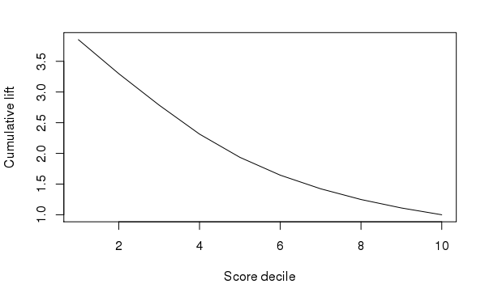

#### Build a glm model

TrainAccuracy TrainKappa TrainROC TrainSens TrainSpec TrainAUC TrainPrecision 1 0.7864355 0.1174352 0.5579789 0.9416025 0.1743553 0.04835679 0.8214544 TrainRecall TrainF method 1 0.9416025 0.8746316 glm

```r
cl <- makePSOCKcluster(10)
registerDoParallel(cl)
set.seed(3)
glm_model <- train(x = select(train_data, vars),
                 y = train_data$lapse,
                 method = "glm",
                 metric = "ROC",
                 trControl = trainControl(method = "cv",
                                          number = 5,
                                          summaryFunction = MySummary,
                                          classProbs = T),
                 family = "binomial")

stopCluster(cl)
getTrainPerf(glm_model)
proc.time() - time_start
```

Validate the model

```r
val_score <- predict(glm_model, newdata = vali_data[, vars], type = "prob")
```

```
Error in eval(predvars, data, env) : object 'Trans_12M_pre' not found
```

#### Build a random forest model

TrainAccuracy TrainKappa TrainROC TrainSens TrainSpec TrainAUC TrainPrecision TrainRecall TrainF method 1 0.8301876 0.4925688 0.8401906 0.9269507 0.5244227 0.9284337 0.8603201 0.9269507 0.892391 rf

```r
cl <- makePSOCKcluster(10)
registerDoParallel(cl)
set.seed(3)
RF_model <- train(x = select(train_data, vars),
                 y = train_data$lapse,
                 method = "rf",
                 metric = "ROC",
                 trControl = trainControl(method = "cv",
                                          number = 5,
                                          summaryFunction = MySummary,
                                          classProbs = T),
                 tuneGrid =  expand.grid(mtry = seq(18, 24, by = 1)))

stopCluster(cl)
getTrainPerf(RF_model)
proc.time() - time_start
ggplot(RF_model)
```

Validate the model

```r
val_score <- predict(RF_model, newdata = vali_data[, vars], type = "prob")

dt = lift(vali_data$lapse == "Yes", val_score[, 2], groups = 10)
dt
plot(dt$bucket, dt$Cumlift, type="l", ylab="Cumulative lift", xlab="Bucket")

## this just validates that highest ventile has the highest score, which is to be expected.
score_ventile = ntile(-val_score[,  2], 20)
barplot(tapply(val_score[, 2], score_ventile, mean), main = "Score vs ventile")

## This proves that highest ventile has the highest % of lapse customers.
vali_data <- vali_data %>%
  mutate(label = lapse == "Yes")
barplot(tapply(vali_data$label, score_ventile, mean), main = "% of lapse vs ventile")
```

#### Compare the three models by considering all the cross validation performance metrics

```r
models <- resamples(list(glm = glm_model, xgboost = xgboost_vars, RF = RF_model))
summary(models)
p1 <- ggplot(models, metric = "Accuracy") + ggtitle("Accuracy")
p2 <- ggplot(models, metric = "AUC") + ggtitle("AUC")
p3 <- ggplot(models, metric = "Sens") + ggtitle("Sensitivity")
p4 <- ggplot(models, metric = "Spec") + ggtitle("Specificity")
grid.arrange(p1, p2, p3, p4, ncol=2)
scales <- list(x=list(relation="free"), y=list(relation="free"))
bwplot(models, scales=scales)
save.image()
```

#### Stacking Algorithms

```r
cl <- makePSOCKcluster(10)
registerDoParallel(cl)
time_start <- proc.time()
trainControl <- trainControl(method="cv",
                             number=5,
                             index = createFolds(train_data$lapse, 5),
                             savePredictions=TRUE,
                             classProbs=TRUE,
                             summaryFunction = MySummary,
                             allowParallel = TRUE)

algorithmList <- c('rf', 'xgbTree', 'xgbLinear', 'glm')

set.seed(100)
models <- caretList(x = select(train_data, vars),
                    y = train_data$lapse,
                    metric="ROC",
                    trControl=trainControl,
                    methodList=algorithmList)
results <- resamples(models)
summary(results)
stopCluster(cl)
proc.time() - time_start
xyplot(results, metric = "ROC")
scales <- list(x=list(relation="free"), y=list(relation="free"))
bwplot(results, scales=scales)
dotplot(results, metric = "ROC")

# We can use the predict function to extract predicitons from this object for new data:
p <- as.data.frame(predict(models, newdata=head(vali_data)))
print(p)
```

#### Print out the performance of each model

```r
print(model_results)
```

```
        glm        RF  XGB_tree XGB_linear svmRadial
1 0.7821401 0.8366121 0.8308172  0.8244517       0.5
```

#### check the correlation between the models.

```r
modelCor(resamples(models))
```

#### Create an ensemble model

```r
greedy_ensemble <- caretEnsemble(
  models,
  metric="ROC",
  trControl=trainControl(
    number=5,
    summaryFunction=MySummary,
    classProbs=TRUE
    ))
summary(greedy_ensemble)


## Validate the ensemble model. Poor model!!!! Overfitting!
val_score <- predict(greedy_ensemble, newdata = vali_data[, vars], type = "prob")
confusionMatrix(as.factor(val_score > 0.5), as.factor(vali_data$lapse == "Yes"), positive = "TRUE")

dt = lift(vali_data$lapse == "Yes", val_score, groups = 10)
dt
plot(dt$bucket, dt$Cumlift, type="l", ylab="Cumulative lift", xlab="Bucket")
```

### Buil the final model using the entire training data.

```r
cl <- makePSOCKcluster(10)
registerDoParallel(cl)
set.seed(3)
xgboost_full <- train(x = select(eligible, vars),
                 y = eligible$lapse,
                 method = "xgbTree",
                 metric = "ROC",
                 trControl = trainControl(method = "none",
                                          classProbs = T),
                 tuneGrid =  expand.grid(nrounds = 3300, #the maximum number of iterations
                                         eta = 0.01, # shrinkage
                                         max_depth = 3, # max depth of a tree
                                         gamma = 1,
                                         colsample_bytree = 0.5,
                                         min_child_weight = 2, # Larger values are more robust than smaller values (less likely to result in overfitting).
                                         subsample = 0.7))
ggplot(varImp(xgboost_full, scale = F))
stopCluster(cl)
proc.time() - time_start
```

Partial dependence plots

Note that we had to remove the outliers and create a new model, otherwise the plots will show the outliers and the insight won’t be as clear.

```r
cl <- makePSOCKcluster(10)
registerDoParallel(cl)
set.seed(3)
xgboost_partial <- train(x = train_data_dedummified[train_data_dedummified$TRANS12X <= 500, vars],
                 y = train_data[train_data$TRANS12X <= 500, ]$lapse,
                 method = "xgbTree",
                 metric = "ROC",
                 trControl = trainControl(method = "none",
                                          classProbs = T),
                 tuneGrid =  expand.grid(nrounds = 3300, #the maximum number of iterations
                                         eta = 0.01, # shrinkage
                                         max_depth = 3, # max depth of a tree
                                         gamma = 1,
                                         colsample_bytree = 0.5,
                                         min_child_weight = 2, # Larger values are more robust than smaller values (less likely to result in overfitting).
                                         subsample = 0.7))
ggplot(varImp(xgboost_partial, scale = F))
stopCluster(cl)

partial(xgboost_partial, pred.var = c("TRANS12X"), prob = T, which.class = 2, plot = T, rug = T, plot.engine = "ggplot")

## if we don't specify prob = T, the values in the chart are log values.
partial(xgboost_partial, pred.var = c("INVLNS12"), which.class = 2, prob =  T, plot = T, rug = T, plot.engine = "ggplot")

partial(xgboost_partial, pred.var = c("Trans_6M_pre"), which.class = 2, prob =  T, plot = T, rug = T, plot.engine = "ggplot")


partial(xgboost_partial, pred.var = c("SHIP_T12X"), which.class = 2, prob =  T, plot = T, rug = T, plot.engine = "ggplot" )

partial(xgboost_partial, pred.var = c("LINES12X"), which.class = 2, prob =  T, plot = T, rug = T, plot.engine = "ggplot")

partial(xgboost_partial, pred.var = c("mrospend"), which.class = 2, prob =  T, plot = T, rug = T, plot.engine = "ggplot")

partial(xgboost_partial, pred.var = c("DISTANCE"), which.class = 2, prob =  T, plot = T, rug = T, plot.engine = "ggplot")

partial(xgboost_partial, pred.var = c("BRRET_S12X"), which.class = 2, prob =  T, plot = T, rug = T, plot.engine = "ggplot")

partial(xgboost_partial, pred.var = c("DUNSYRST"), which.class = 2, prob =  T, plot = T, rug = T, plot.engine = "ggplot")

partial(xgboost_partial, pred.var = c("SAFTS12X_pct"), which.class = 2, prob =  T, plot = T, rug = T, plot.engine = "ggplot")

partial(xgboost_partial, pred.var = c("EPROC_S12X"), which.class = 2, prob =  T, plot = T, rug = T, plot.engine = "ggplot")


# The following code didn't work.
# pdps <- list()
# for (feature in vars[1:10]) {
#   pdps[[feature]] <- partial(xgboost_partial, pred.var = feature,
#                              prob = T, which.class = 2)
# }
# grid.arrange(grobs = pdps, ncol = 3)

train_data <- train_data %>%
  mutate(pred = predict(xgboost_full, newdata = train_data[, vars], type = "prob")[, 2],
         label = ifelse(pred >= 0.5, 1, 0))
ggplot(train_data, aes(x = TRANS12X, y = pred)) +
    geom_point() + xlim(c(0, 500)) +
    ylab("predicted lapse probability")



# ggplot(train_data, aes(x = TRANS12X)) + geom_density(aes(color = as.factor(label))) + xlim(c(0, 500))

# qplot(TRANS12X, data = train_data, geom = "histogram",
#       fill = as.factor(label)) + xlim(c(0, 500))

## good visual
ggplot(train_data, aes(x = TRANS12X)) +
  geom_histogram(aes(color = as.factor(label)), fill = "white", position = "dodge") +
  xlim(c(0, 500))

ggplot(train_data, aes(x = TRANS12X)) + geom_area(aes(fill = as.factor(label)), stat ="bin", alpha=0.6) + xlim(c(0, 500))

### The following two create the same chart with a smooth line.
ggplot(train_data, aes(x = TRANS12X, y = pred)) + geom_point() + geom_smooth(method = "auto") + xlim(c(0, 500))
qplot(TRANS12X, pred, data = train_data,
      geom = c("point", "smooth")) + xlim(c(0, 500))

### Only smooth line, no points.
qplot(TRANS12X, pred, data = train_data, geom = "smooth") + xlim(c(0, 500))

## show % of lapse vs non lapse
ggplot(train_data, aes(x = TRANS12X, fill = lapse)) +
    geom_histogram(position = "fill", bins = 100) + xlim(c(0, 500)) +
    ylab("% of locations")
```

Generate the charts with prefered style. Take sample otherwise it’s much slower.

```r
qplot(TRANS12X, pred, data = sample_frac(train_data, size = 0.1),
      geom = c("point", "smooth")) + ylab("Predicted 3-month-inactive risk") + xlab("Trans 12X") + xlim(c(0, 500))

qplot(INVLNS12, pred, data = sample_frac(train_data, size = 0.1),
      geom = c("point", "smooth")) + ylab("Predicted 3-month-inactive risk") + xlab("Invoice lines 12X") + xlim(c(0, 500))

qplot(Trans_6M_pre, pred, data = sample_frac(train_data, size = 0.1),
      geom = c("point", "smooth")) + ylab("Predicted 3-month-inactive risk") + xlab("Most recent 6 mo. Trans") + xlim(c(0, 500))

qplot(RECENCY, pred, data = sample_frac(train_data, size = 0.1),
      geom =  c("point", "smooth")) + ylab("Predicted 3-month-inactive risk") + xlab("Purchase recency")

qplot(SHIP_T12X, pred, data = sample_frac(train_data, size = 0.1),
      geom = c("point", "smooth")) + ylab("Predicted 3-month-inactive risk") + xlab("Ship Trans 12X") + xlim(c(0, 2500))

qplot(BRRET_S12X, pred, data = sample_frac(train_data, size = 0.1),
      geom = c("point", "smooth")) + ylab("Predicted 3-month-inactive risk") + xlab("Branch Return Sales 12X") + xlim(c(-5000, 0))

qplot(EPROC_S12X, pred, data = sample_frac(train_data, size = 0.1),
      geom = c("point", "smooth")) + ylab("Predicted 3-month-inactive risk") + xlab("Epro Sales 12X") + xlim(c(0, 25000))

qplot(SHIP_T36X, pred, data = sample_frac(train_data, size = 0.1),
      geom = c("point", "smooth")) + ylab("Predicted 3-month-inactive risk") + xlab("Ship Trans 36X") + xlim(c(0, 1000))

qplot(DUNSYRST, pred, data = sample_frac(train_data, size = 0.1),
      geom = c("point", "smooth")) + ylab("Predicted 3-month-inactive risk") + xlab("Year started") + xlim(c(1850, 2018))

qplot(LINES12X, pred, data = sample_frac(train_data, size = 0.1),
      geom = c("point", "smooth")) + ylab("Predicted 3-month-inactive risk") + xlab("# of product segments purchased 12X") + xlim(c(0, 35))

qplot(SAFTS12X_pct, pred, data = sample_frac(train_data, size = 0.1),
      geom = c("point", "smooth")) + ylab("Predicted 3-month-inactive risk") + xlab("% of safty sales 12X") + xlim(c(0, 0.5))

qplot(EPRO_sales_perct, pred, data = sample_frac(train_data, size = 0.1),
      geom = c("point", "smooth")) + ylab("Predicted 3-month-inactive risk") + xlab("% of EPRO sales 12X") + xlim(c(0, 0.8))

train_data <- train_data %>%
  mutate(Ship_trans_perct = SHIP_T12X / TRANS12X,
         Return_Sales_perct = abs(BRRET_S12X) / SALES12X,
         EPRO_sales_perct = EPROC_S12X / SALES12X)

qplot(Ship_trans_perct, pred, data = sample_frac(train_data, size = 0.1),
      geom = c("point", "smooth")) + ylab("Predicted 3-month-inactive risk") + xlab("% of ship trans 12X") + xlim(c(0, 0.8))

qplot(EPRO_sales_perct, pred, data = sample_frac(train_data, size = 0.1),
      geom = c("point", "smooth")) + ylab("Predicted 3-month-inactive risk") + xlab("% of EPRO Sales") + xlim(c(0, 0.8))

qplot(Return_Sales_perct, pred, data = sample_frac(train_data, size = 0.1),
      geom = c("point", "smooth")) + ylab("Predicted 3-month-inactive risk") + xlab("% of branch return Sales") + xlim(c(0, 0.1))


ggplot(train_data, aes(x = Trans_12M_pre, fill = lapse)) +
    geom_bar() + xlim(c(0, 500)) +
    ylab("# of locations")

ggplot(train_data, aes(x = Trans_3M_pre, fill = lapse)) +
  geom_bar() + xlim(c(0, 500)) + ylab("# of locations")

ggplot(train_data, aes(x = INVLNS12, fill = lapse)) +
  geom_bar() + xlim(c(0, 500)) + ylab("# of locations")

ggplot(train_data, aes(x = TENURE, fill = lapse)) +
    geom_histogram(position = "fill", bins = 100) + xlim(c(0, 500)) +
    ylab("% of locations")

ggplot(train_data, aes(x = TENURE, fill = lapse)) +
  geom_bar() + xlim(c(0, 500)) + ylab("# of locations")

ggplot(train_data, aes(x = EPROC_S12X, fill = lapse)) +
    geom_histogram(position = "fill", bins = 100) + xlim(c(0, 50000)) +
    ylab("% of locations")

ggplot(train_data, aes(x = DUNSYRST, fill = lapse)) +
    geom_histogram(position = "fill", bins = 100) + xlim(c(1900, 2020)) +
    ylab("% of locations")

ggplot(train_data, aes(x = DUNSYRST, fill = lapse)) +
  geom_bar() + xlim(c(1900, 2020))  + ylab("# of locations")

ggplot(train_data, aes(x = BRRET_S12X, fill = lapse)) +
    geom_histogram(position = "fill", bins = 100) + xlim(c(-2500, 0)) +
    ylab("% of locations")

ggplot(train_data, aes(x = LINES12X, fill = lapse)) +
    geom_histogram(position = "fill") + xlim(c(0, 36)) +
    ylab("% of locations")

ggplot(train_data, aes(x = SHIP_T12X, fill = lapse)) +
    geom_histogram(position = "fill", bins = 100) +
    ylab("% of locations")

ggplot(train_data, aes(x = SHIP_T12X, fill = lapse)) +
  geom_bar() + xlim(c(0, 20000)) + ylab("# of locations")

ggplot(train_data, aes(x = SAFTS12X_pct, fill = lapse)) +
    geom_histogram(position = "fill", bins = 100) + xlim(c(0, 1)) +
    ylab("% of locations")

ggplot(train_data, aes(x = MAIL12X, fill = lapse)) +
    geom_histogram(position = "fill", bins = 100) + xlim(c(0, 200)) +
    ylab("% of locations")

### Need to de dummify the categorical variables.
ggplot(train_data, aes(x = mro_decile)) + geom_bar(aes(fill = lapse))
```

Excel friendly charts.

```r
train_data <- train_data %>%
  mutate(Trans12x_group = ntile(TRANS12X, 10),
         INVLNS12_group = ntile(INVLNS12, 10),
         Trans_6M_pre_group = ntile(Trans_6M_pre, 10),
         Recency_group = ntile(RECENCY, 10),
         SHIP_T12X_group = ntile(SHIP_T12X, 10),
         Return_Sales_group = ntile(Return_Sales_perct, 10),
         EPRO_sales_group = ntile(EPRO_sales_perct, 10),
         SHIP_T36X_group = ntile(SHIP_T36X, 10),
         MRO_group = ntile(mrospend, 10),
         DUNSYRST_group = ntile(DUNSYRST, 10),
         LINES12X_group = ntile(LINES12X, 10),
         SAFTS12X_pct_group = ntile(SAFTS12X_pct, 10))

train_data %>%
  group_by(Trans12x_group) %>%
  summarise(locations = n(),
            "predicted 3-month-inactive risk" = mean(pred))

train_data %>%
  group_by(INVLNS12_group) %>%
  summarise(locations = n(),
            "predicted 3-month-inactive risk" = mean(pred))

train_data %>%
  group_by(Trans_6M_pre_group) %>%
  summarise(locations = n(),
            "predicted 3-month-inactive risk" = mean(pred))

train_data %>%
  group_by(Recency_group) %>%
  summarise(locations = n(),
            "predicted 3-month-inactive risk" = mean(pred))

train_data %>%
  group_by(SHIP_T12X_group) %>%
  summarise(locations = n(),
            "predicted 3-month-inactive risk" = mean(pred))

train_data %>%
  group_by(Return_Sales_group) %>%
  summarise(locations = n(),
            "predicted 3-month-inactive risk" = mean(pred))

train_data %>%
  group_by(EPRO_sales_group) %>%
  summarise(locations = n(),
            "predicted 3-month-inactive risk" = mean(pred))

train_data %>%
  group_by(SHIP_T36X_group) %>%
  summarise(locations = n(),
            "predicted 3-month-inactive risk" = mean(pred))

train_data %>%
  group_by(MRO_group) %>%
  summarise(locations = n(),
            "predicted 3-month-inactive risk" = mean(pred))

train_data %>%
  group_by(DUNSYRST_group) %>%
  summarise(locations = n(),
            "predicted 3-month-inactive risk" = mean(pred))

train_data %>%
  group_by(LINES12X_group) %>%
  summarise(locations = n(),
            "predicted 3-month-inactive risk" = mean(pred))

train_data %>%
  group_by(SAFTS12X_pct_group) %>%
  summarise(locations = n(),
            "predicted 3-month-inactive risk" = mean(pred))


train_data <- train_data %>%
  mutate(EPRO_sales_range = ifelse(EPRO_sales_perct<= 0.025, "0.025",
                                   ifelse(EPRO_sales_perct<= 0.05, "0.05",
                                          ifelse(EPRO_sales_perct<= 0.1, "0.1",
                                                 ifelse(EPRO_sales_perct <= 0.2, "0.2",
                                                        ifelse(EPRO_sales_perct <= 0.3, "0.3",
                                                               ifelse(EPRO_sales_perct <= 0.4, "0.4",
                                                                      ifelse(EPRO_sales_perct <= 0.5, "0.5",
                                                                             ifelse(EPRO_sales_perct <= 0.6, "0.6",
                                                                                    ifelse(EPRO_sales_perct <= 0.7, "0.7", "0.8"))))))),
                                          Return_Sales_range = ifelse(Return_Sales_perct<= 0.025, "0.025",
                                                                      ifelse(Return_Sales_perct <= 0.05, "0.05",
                                                                             ifelse(Return_Sales_perct <= 0.075, "0.075", 0.1))),
                                          safety_sales_range = ifelse(SAFTS12X_pct<= 0.025, "0.025",
                                                                      ifelse(SAFTS12X_pct<= 0.05, "0.05",
                                                                             ifelse(SAFTS12X_pct <= 0.1, "0.1",
                                                                                    ifelse(SAFTS12X_pct <= 0.2, "0.2",
                                                                                           ifelse(SAFTS12X_pct <= 0.3, "0.3",
                                                                                                  ifelse(SAFTS12X_pct <= 0.4, "0.4",
                                                                                                         ifelse(SAFTS12X_pct <= 0.5, "0.5",
                                                                                                                ifelse(SAFTS12X_pct <= 0.6, "0.6",
                                                                                                                       ifelse(SAFTS12X_pct <= 0.7, "0.7", "0.8"))))))))))))

train_data %>%
  group_by(EPRO_sales_range) %>%
  summarise(locations = n(),
            "predicted 3-month-inactive risk" = mean(pred))

train_data %>%
  group_by(Return_Sales_range) %>%
  summarise(locations = n(),
            "predicted 3-month-inactive risk" = mean(pred))

train_data %>%
  group_by(safety_sales_range) %>%
  summarise(locations = n(),
            "predicted 3-month-inactive risk" = mean(pred))
```

### Validate the model on a different cohort

Construct the validation dataset by taking January model file as independent vars and merging with May model file using Mar-May as dependent var.

Remember to exclude off-account locations.

```r
dep_vars <- fread('/hadoop/grainger/data_science/inputFiles/modelFiles/201905_May_merged_model_file.csv', data.table = F)
dep_vars <- dep_vars %>%
  filter(BUS_LOC_ID != 0 & ACCOUNT %in% c(111111118, 222222226, 244444444) == F) %>%
  mutate(Trans_3M = rowSums(select(., TRANS03:TRANS01))) %>%
  select(ACCOUNT, Trans_3M)
summary(dep_vars$Trans_3M)

ind_vars <- fread('/hadoop/grainger/data_science/inputFiles/modelFiles/201901_Jan_merged_model_file_NEW.csv', data.table = F)

ind_vars <- ind_vars %>%
  filter(ACCOUNT %in% c(111111118, 222222226, 244444444) == F)
```

#### merge the two files using account number first.

- it’s not a good idea to aggregate the two files to BUS LOC level and then merge the two files because bus location ID got re-stated often.

```r
merge_val <- left_join(ind_vars, dep_vars, by = "ACCOUNT")
rm(ind_vars)
rm(dep_vars)
```

#### Function to aggregate the data to location level and feature engineering

```r
loc_aggr_fe_func <- function(x){
  loc_aggr_sum <- x %>%
    group_by(BUS_LOC_ID) %>%
    summarise_at(vars(BRNCH_S12X:INVLNS24, TRANS36:WA_S12X, LINES12X:WLDGN24X, Trans_3M), sum, na.rm = T)
  ### had to split the following commands because otherwise it was taking long.
  x <- x %>% arrange(desc(-BUS_LOC_ID), desc(SALES12X), desc(mrospend))

  loc_aggr_first <- x %>%
    group_by(BUS_LOC_ID) %>%
    summarise_at(vars(CSG, EMPHERE, DUNSYRST:dunspop, indseg1, Corp_Maj_Flag,
                      market_segment), first)

  loc_aggr_min <- x %>%
    group_by(BUS_LOC_ID) %>%
    summarise_at(vars(RECENCY, DISTANCE, mro_decile), min)

  loc_aggr_max <- x %>%
    group_by(BUS_LOC_ID) %>%
    summarise_at(vars(TENURE, mrospend, INVSOLFLG, multisite, CONTRACT_FLAG), max)


  loc_aggr_x <- full_join(loc_aggr_sum, loc_aggr_first) %>%
    full_join(loc_aggr_min) %>%
    full_join(loc_aggr_max)

  rm(loc_aggr_first)
  rm(loc_aggr_sum)
  rm(loc_aggr_min)
  rm(loc_aggr_max)
  loc_aggr_x <- ungroup(loc_aggr_x)

  ## feature engineering
  loc_aggr_x <- loc_aggr_x %>%
    filter(BUS_LOC_ID != 0) %>%
    mutate(BUS_LOC_ID = as.character(BUS_LOC_ID),
           mro_decile = as.factor(mro_decile),
           Corp_Maj_Flag = as.factor(Corp_Maj_Flag),
           multisite = as.factor(multisite),
           indseg1 = as.factor(indseg1),
           CONTRACT_FLAG = as.factor(CONTRACT_FLAG),
           coverage = ifelse(substr(CSG, 1, 2) %in% seq(72, 78), "ISA",
                             ifelse(substr(CSG, 1, 2) %in% c(84, 88), "AM",
                                    ifelse(substr(CSG, 1, 2) == 83, "FAR",
                                           ifelse(substr(CSG, 1, 2) == 89, "Gov ARM",
                                                  "Uncovered")))),
           coverage = as.factor(coverage),
           dunsman = as.factor(dunsman),
           dunsstat = as.factor(dunsstat),
           dunssub = as.factor(dunssub),
           Trans_3M_pre = rowSums(select(., TRANS03:TRANS01)),
           Trans_6M_pre = rowSums(select(., TRANS06:TRANS01)),
           Trans_12M_pre = rowSums(select(., TRANS12:TRANS01)),
           SALES_3M_pre = rowSums(select(., SALES03:SALES01)),
           SALES_6M_pre = rowSums(select(., SALES06:SALES01)),
           SALES_12M_pre = rowSums(select(., SALES12:SALES01))
    )

pct_cal <- sapply(names(loc_aggr_x)[which(colnames(loc_aggr_x) == "ABRVS12X"):which(colnames(loc_aggr_x) == "WLDGS12X")], function(x) {
  loc_aggr_x[paste0(x, "_pct")] <<- loc_aggr_x[x] / loc_aggr_x$SALES12X
})
rm(pct_cal)
colnames(loc_aggr_x) <- make.names(names(loc_aggr_x), unique=TRUE)


### create dummy variables.
loc_aggr_x <- loc_aggr_x %>%
  to_dummy(c(Corp_Maj_Flag, mro_decile, indseg1, CONTRACT_FLAG, multisite, coverage, dunsstat, dunssub, dunsman), suffix = "label") %>%
  bind_cols(loc_aggr_x) %>%
  select(BUS_LOC_ID:DISTANCE, everything())

return(loc_aggr_x)
}
```

#### Execute the location aggr and feature engineering function

```r
merge_val  <- loc_aggr_fe_func(merge_val )
sort(colSums(is.na(merge_val)))

### Take care of missing values
merge_val  <- merge_val  %>%
  mutate(DISTANCE= ifelse(is.na(DISTANCE), mean(DISTANCE, na.rm=TRUE), DISTANCE)) %>%
  replace(is.na(.), 0)

sort(colSums(is.na(merge_val )))
which(sapply(merge_val, is.factor))
which(sapply(merge_val, is.character))
sapply(merge_val, class)
```

#### compare the stats of lapsed locations from different cohort

```r
merge_val <- merge_val %>%
  mutate(Trans_3M = ifelse(is.na(Trans_3M), 0, Trans_3M),
         lapse = ifelse(Trans_3M == 0, "Yes", "No"))

prop.table(table(filter(merge_val, TRANS01 > 0)$lapse))

### Look at volume.
merge_val %>%
  filter(TRANS01 > 0) %>%
  group_by(lapse) %>%
  summarise(count = n(),
            sales_avg = mean(SALES12X),
            sales = sum(SALES12X))

merge_val %>%
  select(-Trans_3M) %>%
  mutate(Trans_3M = rowSums(select(., TRANS03:TRANS01)),
         Trans_3M = ifelse(is.na(Trans_3M), 0, Trans_3M),
         lapse = ifelse(Trans_3M == 0, "Yes", "No"),
         sales_pre12 = rowSums(select(., SALES16:SALES05))) %>%
  filter(TRANS05 > 0) %>%
  group_by(lapse) %>%
  summarise(count = n(),
            sales_avg = mean(sales_pre12),
            sales = sum(sales_pre12))

merge_val %>%
  select(-Trans_3M) %>%
  mutate(Trans_3M = rowSums(select(., TRANS04:TRANS02)),
         Trans_3M = ifelse(is.na(Trans_3M), 0, Trans_3M),
         lapse = ifelse(Trans_3M == 0, "Yes", "No"),
         sales_pre12 = rowSums(select(., SALES17:SALES06))) %>%
  filter(TRANS06 > 0) %>%
  group_by(lapse) %>%
  summarise(count = n(),
            sales_avg = mean(sales_pre12),
            sales = sum(sales_pre12))
```

#### Validate the model on the new dataset constructed by Jan 2019 cohort.

```r
val_score <- predict(xgboost_full, newdata = merge_val[merge_val$TRANS01 > 0, vars], type = "prob")
dt = lift(merge_val[merge_val$TRANS01 > 0, ]$lapse == "Yes", val_score[, 2], groups = 10)
dt
plot(dt$bucket, dt$Cumlift, type="l", ylab="Cumulative lift", xlab="Bucket")

confusionMatrix(as.factor(val_score[, 2] > 0.5), as.factor(merge_val[merge_val$TRANS01 > 0, ]$lapse == "Yes"), positive = "TRUE")
```

### Profile the customers

```r
profiling <- merge_val %>%
  select(-lapse, -SALES_12M_pre) %>%
  filter(TRANS01 > 0) %>%
  mutate(lapse = ifelse(Trans_3M == 0, "Yes", "No"))

## Reverse dummy coding
library(tidyverse)
Corp_Maj_Flag <-profiling[, 299:306] %>% gather(Corp_Maj_Flag, Count) %>% filter(Count >= 1) %>%
  select(Corp_Maj_Flag)

mro_decile <- profiling[, 307:316] %>% gather(mro_decile, Count) %>% filter(Count >= 1) %>%
  select(mro_decile)

industry <- profiling[, 317:331] %>% gather(industry, Count) %>% filter(Count >= 1) %>%
  select(industry)

coverage <- profiling[, 336:340] %>% gather(coverage, Count) %>% filter(Count >= 1) %>%
  select(coverage)

Corp_Maj_Flag <-profiling[, 299:306] %>% gather(Corp_Maj_Flag, Count) %>%
  select(Corp_Maj_Flag)

mro_decile <- profiling[, 307:316] %>% gather(mro_decile, Count) %>%
  select(mro_decile)

industry <- profiling[, 317:331] %>% gather(industry, Count) %>%
  select(industry)

coverage <- profiling[, 336:340] %>% gather(coverage, Count) %>%
  select(coverage)

profiling <- cbind(profiling, Corp_Maj_Flag, mro_decile, industry, coverage)
rm(Corp_Maj_Flag)
rm(mro_decile)
rm(industry)
rm(coverage)
names(profiling)


prop.table(table(profiling$lapse))
tapply(profiling$mrospend, profiling$lapse, mean)
tapply(profiling$TRANS12X, profiling$lapse, mean)
tapply(profiling$SALES12X, profiling$lapse, mean)
profiling %>% group_by(mro_decile) %>% summarise(lapse_rate = mean(lapse == "Yes"))
profiling %>% group_by(industry) %>% summarise(lapse_rate = mean(lapse == "Yes"))
profiling %>%
  group_by(industry, lapse) %>%
  summarise(locations = n(),
            sales12x = sum(SALES12X)) %>%
  mutate(locs_perct = locations / sum(locations),
         sales_perct = sales12x / sum(sales12x))
tapply(profiling$lapse == "Yes", profiling$Corp_Maj_Flag, mean)
tapply(profiling$lapse == "Yes", profiling$coverage, mean)

### It looks like using mro_decile and mro_decile_10 result in different numbers!!
profiling %>%
  group_by(mro_decile) %>%
  summarise(locations = n(),
            lapse_locs = sum(lapse == "Yes"),
            lapse_rate = mean(lapse == "Yes"))

profiling %>%
  group_by(indseg1) %>%
  summarise(locations = n(),
            lapse_locs = sum(lapse == "Yes"),
            lapse_rate = mean(lapse == "Yes"))

profiling %>%
  group_by(coverage) %>%
  summarise(locations = n(),
            lapse_locs = sum(lapse == "Yes"),
            lapse_rate = mean(lapse == "Yes"))
```

Model Scoring ################################################################################

### Import file for scoring

```r
scoring <- fread('/hadoop/grainger/data_science/inputFiles/modelFiles/201907_Jul_merged_model_file.csv', data.table = F)
```

```
|--------------------------------------------------|
|==================================================|
```

```r
on_account <- scoring %>%
  mutate(on_account = ifelse(ACCOUNT > 800000000, 1, 0))%>%
  group_by(BUS_LOC_ID) %>%
  summarise(on_account_locs = sum(on_account)) %>%
  ungroup()
scoring <- inner_join(scoring, on_account, by = "BUS_LOC_ID") %>%
  filter(on_account_locs >= 1)
# summary(scoring$on_account_locs)
```

### Aggregate to location level

```r
loc_aggr_sum <- scoring %>%
  group_by(BUS_LOC_ID) %>%
  summarise_at(vars(BRNCH_S12X:INVLNS24, TRANS36:WA_S12X, LINES12X:WLDGN24X), sum, na.rm = T)
### had to split the following commands because otherwise it was taking long.
scoring <- scoring %>% arrange(desc(-BUS_LOC_ID), desc(SALES12X), desc(mrospend))

loc_aggr_first <- scoring %>%
  group_by(BUS_LOC_ID) %>%
  summarise_at(vars(CSG, EMPHERE, DUNSYRST:dunspop, indseg1, Corp_Maj_Flag, market_segment), first)

loc_aggr_min <- scoring %>%
  group_by(BUS_LOC_ID) %>%
  summarise_at(vars(RECENCY, DISTANCE, mro_decile, FIRST_PURCH_DT), min)

loc_aggr_max <- scoring %>%
  group_by(BUS_LOC_ID) %>%
  summarise_at(vars(TENURE, mrospend, INVSOLFLG, multisite, CONTRACT_FLAG), max)


loc_aggr_scoring <- full_join(loc_aggr_sum, loc_aggr_first) %>%
  full_join(loc_aggr_min) %>%
  full_join(loc_aggr_max)

rm(loc_aggr_first)
rm(loc_aggr_sum)
rm(loc_aggr_min)
rm(loc_aggr_max)
loc_aggr_scoring <- ungroup(loc_aggr_scoring)
str(loc_aggr_scoring)
rm(scoring)
```

### feature engineering on scoring data

```r
loc_aggr_scoring <- loc_aggr_scoring %>%
  filter(BUS_LOC_ID != 0) %>%
  mutate(BUS_LOC_ID = as.character(BUS_LOC_ID),
         mro_decile = as.factor(mro_decile),
         Corp_Maj_Flag = as.factor(Corp_Maj_Flag),
         multisite = as.factor(multisite),
         indseg1 = as.factor(indseg1),
         CONTRACT_FLAG = as.factor(CONTRACT_FLAG),
         coverage = ifelse(substr(CSG, 1, 2) %in% seq(72, 78), "ISA",
                           ifelse(substr(CSG, 1, 2) %in% c(84, 88), "AM",
                                  ifelse(substr(CSG, 1, 2) == 83, "FAR",
                                         ifelse(substr(CSG, 1, 2) == 89, "Gov ARM",
                                                       "Uncovered")))),
         coverage = ifelse(is.na(coverage), "Uncovered", coverage),
         coverage = as.factor(coverage),
         dunsman = as.factor(dunsman),
         dunsstat = as.factor(dunsstat),
         dunssub = as.factor(dunssub),
         Trans_3M_pre = rowSums(select(., TRANS03:TRANS01)),
         Trans_6M_pre = rowSums(select(., TRANS06:TRANS01)),
         Trans_12M_pre = rowSums(select(., TRANS12:TRANS01)),
         SALES_3M_pre = rowSums(select(., SALES03:SALES01)),
         SALES_6M_pre = rowSums(select(., SALES06:SALES01)),
         SALES_12M_pre = rowSums(select(., SALES12:SALES01))
         )
### Create tenure_adj variable based on first_purch_DT.
loc_aggr_scoring <- loc_aggr_scoring %>%
  mutate(FIRST_PURCH_DT = as.Date(FIRST_PURCH_DT, "%m/%d/%Y"),
    tenure_adj = ifelse(is.na(FIRST_PURCH_DT) != T, interval(FIRST_PURCH_DT, as.Date('7/29/2019', "%m/%d/%Y")) %/% months(1) + 1,
                        ifelse(is.na(FIRST_PURCH_DT) & TENURE >= interval(ymd("20160101"), ymd("20190729")) %/% months(1), TENURE,
                               ifelse(is.na(FIRST_PURCH_DT) & SALES12X > 0 & SALES24X + SALES36X == 0, 6, 18))),
    active13 = rowSums(select(., TRANS24:TRANS13)) > 0,
    new_flag = tenure_adj >=1 & tenure_adj <=12 & active13 == F)
# sanity check
table(loc_aggr_scoring$new_flag)
```

```
  FALSE    TRUE
4525800  108173
```

```r
View(select(loc_aggr_scoring, BUS_LOC_ID, FIRST_PURCH_DT, TENURE, tenure_adj, new_flag))
### Above we filter out new customers, but moving forward we may need to just exclude the customers who are in the early life cycle program, it could be 6 months or 3 months, etc.
pct_cal <- sapply(names(loc_aggr_scoring)[which(colnames(loc_aggr_scoring) == "ABRVS12X"):which(colnames(loc_aggr_scoring) == "WLDGS12X")], function(x) {
  loc_aggr_scoring[paste0(x, "_pct")] <<- loc_aggr_scoring[x] / loc_aggr_scoring$SALES12X
})
rm(pct_cal)
colnames(loc_aggr_scoring) <- make.names(names(loc_aggr_scoring), unique=TRUE)
names(loc_aggr_scoring)
```

```
  [1] "BUS_LOC_ID"     "BRNCH_S12X"     "PHONE_S12X"     "GDCOM_S12X"
  [5] "EPROC_S12X"     "KPSTK_S12X"     "OOTHR_S12X"     "SALES12X"
  [9] "SHIP_S12X"      "CNTR_S12X"      "WCAL_S12X"      "BRRET_S12X"
 [13] "DCRET_S12X"     "BRNCH_S24X"     "PHONE_S24X"     "GDCOM_S24X"
 [17] "EPROC_S24X"     "KPSTK_S24X"     "OOTHR_S24X"     "SALES24X"
 [21] "SHIP_S24X"      "CNTR_S24X"      "WCAL_S24X"      "BRRET_S24X"
 [25] "DCRET_S24X"     "BRNCH_S36X"     "PHONE_S36X"     "GDCOM_S36X"
 [29] "EPROC_S36X"     "KPSTK_S36X"     "OOTHR_S36X"     "SALES36X"
 [33] "SHIP_S36X"      "CNTR_S36X"      "WCAL_S36X"      "BRRET_S36X"
 [37] "DCRET_S36X"     "BRNCH_T12X"     "PHONE_T12X"     "GDCOM_T12X"
 [41] "EPROC_T12X"     "KPSTK_T12X"     "OOTHR_T12X"     "TRANS12X"
 [45] "SHIP_T12X"      "CNTR_T12X"      "WCAL_T12X"      "BRRET_T12X"
 [49] "DCRET_T12X"     "BRNCH_T24X"     "PHONE_T24X"     "GDCOM_T24X"
 [53] "EPROC_T24X"     "KPSTK_T24X"     "OOTHR_T24X"     "TRANS24X"
 [57] "SHIP_T24X"      "CNTR_T24X"      "WCAL_T24X"      "BRRET_T24X"
```

[output cut: 74 more lines]

- Create dummy variables Check how many factor variables are there in the dataset and create dummy variables Leave dummy variables as numeric because xgboost only takes in numeric variables.

```r
names(Filter(is.factor, loc_aggr_scoring))
```

```
[1] "dunsstat"      "dunssub"       "dunsman"       "indseg1"
[5] "Corp_Maj_Flag" "mro_decile"    "multisite"     "CONTRACT_FLAG"
[9] "coverage"
```

```r
loc_aggr_scoring <- loc_aggr_scoring %>%
  to_dummy(c(Corp_Maj_Flag, mro_decile, indseg1, CONTRACT_FLAG, multisite, coverage, dunsstat, dunssub, dunsman), suffix = "label") %>%
  bind_cols(loc_aggr_scoring) %>%
  select(BUS_LOC_ID:DISTANCE, everything())
names(Filter(is.factor, loc_aggr_scoring))
```

```
[1] "dunsstat"      "dunssub"       "dunsman"       "indseg1"
[5] "Corp_Maj_Flag" "mro_decile"    "multisite"     "CONTRACT_FLAG"
[9] "coverage"
```

#### Inspect the final dataset

Recode distance and sales by Boldt’s segmentation (those locations didn’t have sales that fall into the segmentations). Recode multiple columns from missing values to zero. Missing values happen because - - some number of locations didn’t have sales that fall into the Boldt segmentation - divide by zero sales12x.

Drop empty levels for factor variables.

```r
sort(colSums(is.na(loc_aggr_scoring)))
loc_aggr_scoring <- loc_aggr_scoring %>%
  mutate(DISTANCE= ifelse(is.na(DISTANCE), mean(DISTANCE, na.rm=TRUE), DISTANCE)) %>%
  select(-FIRST_PURCH_DT) %>%
  replace(is.na(.), 0)

sort(colSums(is.na(loc_aggr_scoring)))
which(sapply(loc_aggr_scoring, is.factor))
which(sapply(loc_aggr_scoring, is.character))
sapply(loc_aggr_scoring, class)
```

#### Make predictions and save the file

```r
lapse_score <- predict(xgboost_full, newdata = loc_aggr_scoring[, vars], type = "prob")
loc_aggr_scoring <- loc_aggr_scoring %>%
  mutate(lapse_score = lapse_score[, 2])
rm(lapse_score)
```

### Import goals data and aggregate to location level

Make sure to customize month range for goals.

```r
goals <- fread('goals.csv', data.table = F)
goals_aggr <- goals %>%
  filter(BUS_LOC_ID != 0) %>%
  group_by(BUS_LOC_ID) %>%
  summarise_at(vars(Jul_Goal:Dec_Goal), sum, na.rm = T) %>%
  ungroup() %>%
  mutate(BUS_LOC_ID = as.character(BUS_LOC_ID),
         sales_goals = rowSums(select(., Aug_Goal:Oct_Goal)))
rm(goals)
```

### Merge with scoring data

```r
loc_aggr_scoring <- left_join(loc_aggr_scoring, goals_aggr) %>%
  replace(is.na(.), 0)
sort(colSums(is.na(loc_aggr_scoring)))
```

### Comparing highest risk customers under different definitions of dollars at risk

```r
loc_aggr_scoring <- loc_aggr_scoring %>%
  mutate(dollars_at_risk_3M_pre = SALES_3M_pre,
         dollars_at_risk_12M_pre = SALES_12M_pre/4,
         dollars_at_risk_goals = sales_goals,
         dollars_at_risk_py_sales = rowSums(select(., SALES11:SALES09)))
# top_decile_3M <- eligible_scoring %>%
#   arrange(desc(dollars_at_risk_3M_pre)) %>%
#   filter(row_number() / n() <= .2) %>%
#   select(BUS_LOC_ID, lapse_score, dollars_at_risk_3M_pre, SALES_3M_pre)
#
# top_decile_12M <- eligible_scoring %>%
#   arrange(desc(dollars_at_risk_12M_pre)) %>%
#   filter(row_number() / n() <= .2) %>%
#   select(BUS_LOC_ID, lapse_score, dollars_at_risk_12M_pre, SALES_12M_pre)
#
# top_decile_goals <- eligible_scoring %>%
#   arrange(desc(dollars_at_risk_goals)) %>%
#   filter(row_number() / n() <= .2) %>%
#   select(BUS_LOC_ID, lapse_score, dollars_at_risk_goals, sales_goals)
# merge_top <- full_join(top_decile_3M, top_decile_goals, by = c("BUS_LOC_ID", "lapse_score")) %>%
#   full_join(top_decile_12M, by = c("BUS_LOC_ID", "lapse_score"))
# sort(colSums(is.na(merge_top)))
```

### Define the dollars at risk

Max of sales goals, py sales, R12 sales.

```r
loc_aggr_scoring <- loc_aggr_scoring %>%
  mutate(dollars_at_risk = pmax(dollars_at_risk_3M_pre, dollars_at_risk_12M_pre,
                                dollars_at_risk_goals, dollars_at_risk_py_sales)) %>%
  select(BUS_LOC_ID, lapse_score, dollars_at_risk_3M_pre:dollars_at_risk_py_sales, dollars_at_risk, everything())
```

#### Only look at 3-month active locations

```r
# eligible_scoring <- eligible_scoring %>%
#   filter(TRANS12X > 0)
# eligible_scoring <- eligible_scoring %>%
#   filter(Trans_6M_pre > 0 & new_flag == F)
eligible_scoring <- loc_aggr_scoring %>%
  filter(Trans_3M_pre > 0 & new_flag == F)
# eligible_scoring <- eligible_scoring %>%
#   filter(TRANS01 > 0 & new_flag == F)
# eligible_scoring <- eligible_scoring %>%
#   filter(new_flag == T)
```

Get some stats on the groups ranked by expected revenue loss.

```r
eligible_scoring <- eligible_scoring %>%
  mutate(exp_rev_loss = dollars_at_risk * lapse_score,
         rank_exp_loss = ntile(-exp_rev_loss, 10))
eligible_scoring %>%
  group_by(rank_exp_loss) %>%
  summarise(locs = n(),
            avg_lapse_prob = mean(lapse_score),
            avg_revenue_risk = mean(dollars_at_risk),
            avg_exp_loss = mean(exp_rev_loss),
            exp_loss_total = sum(exp_rev_loss),
            avg_R12_sales = mean(SALES12X),
            avg_mro = mean(mrospend),
            TRANS12X = mean(TRANS12X),
            LINES12X = mean(LINES12X))
```

| rank_exp_loss | locs | avg_lapse_prob | avg_revenue_risk | avg_exp_loss | exp_loss_total | avg_R12_sales | avg_mro | TRANS12X | LINES12X |
| --- | --- | --- | --- | --- | --- | --- | --- | --- | --- |
| 1 | 45552 | 0.4360791 | 6956.843 | 1068.322767 | 48664238.7 | 14634.282 | 67707.44 | 27.73397 | 5.272568 |
| 2 | 45551 | 0.4089613 | 2788.672 | 287.842867 | 13111530.4 | 6713.728 | 42384.55 | 18.09416 | 5.375623 |
| 3 | 45551 | 0.3923952 | 2591.635 | 183.926319 | 8378027.7 | 6404.652 | 40437.86 | 17.58174 | 5.629119 |
| 4 | 45552 | 0.3758401 | 2722.426 | 129.718460 | 5908935.3 | 7223.225 | 41629.71 | 20.06891 | 5.872234 |
| 5 | 45551 | 0.3610215 | 3083.344 | 93.858042 | 4275327.7 | 8250.253 | 44324.60 | 25.03131 | 6.209172 |
| 6 | 45551 | 0.3418056 | 4058.405 | 67.333428 | 3067105.0 | 11572.821 | 50420.83 | 33.40449 | 6.972844 |
| 7 | 45552 | 0.3087891 | 5694.609 | 46.317881 | 2109872.1 | 16607.439 | 58888.99 | 48.32837 | 8.390674 |
| 8 | 45551 | 0.2639768 | 8279.801 | 29.411689 | 1339731.8 | 24568.090 | 77639.83 | 74.95695 | 10.946500 |
| 9 | 45551 | 0.1951621 | 10552.034 | 16.768024 | 763800.2 | 31791.220 | 95549.38 | 104.01719 | 14.716779 |
| 10 | 45551 | 0.1385036 | 12200.113 | 7.092471 | 323069.1 | 37851.514 | 130505.93 | 141.55101 | 20.131830 |

```r
eligible_scoring <- eligible_scoring %>%
  select(BUS_LOC_ID, lapse_score, dollars_at_risk, exp_rev_loss, rank_exp_loss, everything())
### by decile range
eligible_scoring %>%
  mutate(rank_exp_loss_range = ifelse(rank_exp_loss == 1, "Decile 1",
                                      ifelse(rank_exp_loss <= 4, "Decile 2-4",
                                             ifelse(rank_exp_loss <= 7, "Decile 5-7", "Decile 8-10")))) %>%
  group_by(rank_exp_loss_range) %>%
  summarise(locs = n(),
            avg_lapse_prob = mean(lapse_score),
            avg_exp_loss = mean(exp_rev_loss),
            avg_R12_sales = mean(SALES12X),
            avg_mro = mean(mrospend),
            TRANS12X = mean(TRANS12X),
            LINES12X = mean(LINES12X),
            avg_monthly_sales = mean(SALES12X)/12) %>%
  select(-rank_exp_loss_range) %>%
  transpose() %>%
  bind_cols(loc_aggr_scoring %>%
              filter(TRANS12X > 0) %>%
              mutate(exp_rev_loss = dollars_at_risk * lapse_score,
                     rank_exp_loss = ntile(-exp_rev_loss, 10)) %>%
              summarise(locs = n(),
                        avg_lapse_prob = mean(lapse_score),
                        avg_exp_loss = mean(exp_rev_loss),
                        avg_R12_sales = mean(SALES12X),
                        avg_mro = mean(mrospend),
                        TRANS12X = mean(TRANS12X),
                        LINES12X = mean(LINES12X),
                        avg_monthly_sales = mean(SALES12X)/12) %>%
              transpose())
```

```
            V1           V2           V3           V4          V11
1 4.555200e+04 1.366540e+05 1.366540e+05 1.366530e+05 8.632220e+05
2 4.360791e-01 3.923988e-01 3.372052e-01 1.992142e-01 5.305290e-01
3 1.068323e+03 2.004954e+02 6.916962e+01 1.775739e+01 2.120686e+02
4 1.463428e+04 6.780538e+03 1.214354e+04 3.140361e+04 9.102911e+03
5 6.770744e+04 4.148404e+04 5.121153e+04 1.012317e+05 4.281769e+04
6 2.773397e+01 1.858161e+01 3.558815e+01 1.068417e+02 2.851489e+01
7 5.272568e+00 5.625660e+00 7.190905e+00 1.526504e+01 5.703197e+00
8 1.219524e+03 5.650449e+02 1.011961e+03 2.616967e+03 7.585759e+02
```

```r
eligible_scoring <- eligible_scoring %>%
  select(BUS_LOC_ID, lapse_score, dollars_at_risk, exp_rev_loss, rank_exp_loss, everything())
save(eligible_scoring, xgboost_full, xgboost_vars, vars, loc_aggr_scoring, file = "scoring.RData")
```

More stats for each decile of expected revenue loss

```r
eligible_scoring %>%
  group_by(rank_exp_loss) %>%
  summarise(locs = n(),
            contract_perct = mean(CONTRACT_FLAG ==  1),
            coverage_perct = mean(coverage != "Uncovered"),
            SALES12X = sum(SALES12X),
            SALES24X = sum(SALES24X),
            GDCOM_S12X = sum(GDCOM_S12X),
            BRNCH_S12X = sum(BRNCH_S12X),
            PHONE_S12X = sum(PHONE_S12X),
            EPROC_S12X = sum(EPROC_S12X),
            KPSTK_S12X = sum(KPSTK_S12X),
            SHIP_S12X = sum(SHIP_S12X),
            CNTR_S12X = sum(CNTR_S12X),
            WCAL_S12X = sum(WCAL_S12X),
            SAFTS12X = sum(SAFTS12X),
            HVACS12X = sum(HVACS12X),
            MTHDS12X = sum(MTHDS12X)) %>%
  mutate(Sales_V = SALES12X / SALES24X - 1,
         Gcom_perct = GDCOM_S12X / SALES12X,
         Epro_perct = EPROC_S12X / SALES12X,
         Branch_perct = BRNCH_S12X / SALES12X,
         Phone_perct = PHONE_S12X / SALES12X,
         KS_perct = KPSTK_S12X / SALES12X,
         Ship_perct = SHIP_S12X / SALES12X,
         CNTR_perct = CNTR_S12X / SALES12X,
         WCAL_perct = WCAL_S12X / SALES12X,
         Safety_perct = SAFTS12X / SALES12X,
         HVAC_perct = HVACS12X / SALES12X,
         MTHD_perct = MTHDS12X / SALES12X) %>%
  select(rank_exp_loss, contract_perct:coverage_perct, Sales_V:MTHD_perct)

### by decile range
eligible_scoring %>%
  mutate(rank_exp_loss_range = ifelse(rank_exp_loss == 1, "Decile 1",
                                      ifelse(rank_exp_loss <= 4, "Decile 2-4",
                                             ifelse(rank_exp_loss <= 7, "Decile 5-7", "Decile 8-10")))) %>%
  group_by(rank_exp_loss_range) %>%
  summarise(locs = n(),
            contract_perct = mean(CONTRACT_FLAG ==  1),
            coverage_perct = mean(coverage != "Uncovered"),
            SALES12X = sum(SALES12X),
            SALES24X = sum(SALES24X),
            GDCOM_S12X = sum(GDCOM_S12X),
            BRNCH_S12X = sum(BRNCH_S12X),
            PHONE_S12X = sum(PHONE_S12X),
            EPROC_S12X = sum(EPROC_S12X),
            KPSTK_S12X = sum(KPSTK_S12X),
            SHIP_S12X = sum(SHIP_S12X),
            CNTR_S12X = sum(CNTR_S12X),
            WCAL_S12X = sum(WCAL_S12X),
            SAFTS12X = sum(SAFTS12X),
            HVACS12X = sum(HVACS12X),
            MTHDS12X = sum(MTHDS12X)) %>%
  mutate(Sales_V = SALES12X / SALES24X - 1,
         Gcom_perct = GDCOM_S12X / SALES12X,
         Epro_perct = EPROC_S12X / SALES12X,
         Branch_perct = BRNCH_S12X / SALES12X,
         Phone_perct = PHONE_S12X / SALES12X,
         KS_perct = KPSTK_S12X / SALES12X,
         Ship_perct = SHIP_S12X / SALES12X,
         CNTR_perct = CNTR_S12X / SALES12X,
         WCAL_perct = WCAL_S12X / SALES12X,
         Safety_perct = SAFTS12X / SALES12X,
         HVAC_perct = HVACS12X / SALES12X,
         MTHD_perct = MTHDS12X / SALES12X) %>%
  select(contract_perct:coverage_perct, Sales_V:MTHD_perct) %>%
  transpose() %>%
  bind_cols(loc_aggr_scoring %>%
              filter(TRANS12X > 0) %>%
              mutate(exp_rev_loss = dollars_at_risk * lapse_score,
                     rank_exp_loss = ntile(-exp_rev_loss, 10)) %>%
              summarise(locs = n(),
                        contract_perct = mean(CONTRACT_FLAG ==  1),
                        coverage_perct = mean(coverage != "Uncovered"),
                        SALES12X = sum(SALES12X),
                        SALES24X = sum(SALES24X),
                        GDCOM_S12X = sum(GDCOM_S12X),
                        BRNCH_S12X = sum(BRNCH_S12X),
                        PHONE_S12X = sum(PHONE_S12X),
                        EPROC_S12X = sum(EPROC_S12X),
                        KPSTK_S12X = sum(KPSTK_S12X),
                        SHIP_S12X = sum(SHIP_S12X),
                        CNTR_S12X = sum(CNTR_S12X),
                        WCAL_S12X = sum(WCAL_S12X),
                        SAFTS12X = sum(SAFTS12X),
                        HVACS12X = sum(HVACS12X),
                        MTHDS12X = sum(MTHDS12X)) %>%
              mutate(Sales_V = SALES12X / SALES24X - 1,
                     Gcom_perct = GDCOM_S12X / SALES12X,
                     Epro_perct = EPROC_S12X / SALES12X,
                     Ecom_perct = Gcom_perct + Epro_perct,
                     Branch_perct = BRNCH_S12X / SALES12X,
                     Phone_perct = PHONE_S12X / SALES12X,
                     KS_perct = KPSTK_S12X / SALES12X,
                     Ship_perct = SHIP_S12X / SALES12X,
                     CNTR_perct = CNTR_S12X / SALES12X,
                     WCAL_perct = WCAL_S12X / SALES12X,
                     Safety_perct = SAFTS12X / SALES12X,
                     HVAC_perct = HVACS12X / SALES12X,
                     MTHD_perct = MTHDS12X / SALES12X) %>%
  select(contract_perct:coverage_perct, Sales_V:MTHD_perct) %>%
  transpose())



eligible_scoring %>%
  filter(rank_exp_loss == 1) %>%
  group_by(mro_decile) %>%
  tally()

eligible_scoring %>%
  filter(rank_exp_loss == 1) %>%
  group_by(indseg1) %>%
  tally()

loc_aggr_scoring %>%
  filter(TRANS12X > 0) %>%
  mutate(exp_rev_loss = dollars_at_risk * lapse_score,
         rank_exp_loss = ntile(-exp_rev_loss, 10)) %>%
  group_by(indseg1) %>%
  summarise(locs = n())


eligible_scoring %>%
  filter(rank_exp_loss == 1) %>%
  group_by(coverage) %>%
  tally()

eligible_scoring %>%
  filter(rank_exp_loss == 1) %>%
  group_by(CONTRACT_FLAG) %>%
  tally()

eligible_scoring %>%
  filter(rank_exp_loss == 1) %>%
  summarise(sales12x = mean(SALES12X))
```

### Test design

```r
### Remove outliers and then compare test/control group.
### Decile 1
set.seed(1)
eligible_scoring %>%
  arrange(desc(SALES_3M_pre)) %>%
  filter(rank_exp_loss == 1 & SALES_3M_pre <= quantile(SALES_3M_pre, 0.9999)) %>%
  mutate(group = ifelse(runif(nrow(filter(eligible_scoring, rank_exp_loss == 1 & SALES_3M_pre <= quantile(SALES_3M_pre, 0.9999)))) >= 0.5, "Test", "Control")) %>%
  group_by(group) %>%
  summarise(count = n(),
            mean = mean(SALES_3M_pre),
            sd = sd(SALES_3M_pre))

## Decile 2-4
set.seed(2)
decile_2_4 <- eligible_scoring %>%
  arrange(desc(SALES_3M_pre)) %>%
  filter(rank_exp_loss %in% seq(2, 4, by = 1)) %>%
  sample_frac(size = 0.3) %>%
  filter(SALES_3M_pre <= quantile(SALES_3M_pre, 0.999))
set.seed(2)
decile_2_4 %>%
  mutate(group = ifelse(runif(nrow(decile_2_4)) >= 0.5, "Test", "Control")) %>%
  group_by(group) %>%
  summarise(count = n(),
            mean = mean(SALES_3M_pre),
            sd = sd(SALES_3M_pre))

## Decile 5-7
## take samples to create test/control otherwise the circulation will be too large.
set.seed(2)
decile_5_7 <- eligible_scoring %>%
  arrange(desc(SALES_3M_pre)) %>%
  filter(rank_exp_loss %in% seq(5,7,1)) %>%
  sample_frac(size = 0.2) %>%
  filter(SALES_3M_pre <= quantile(SALES_3M_pre, 0.9999))
set.seed(2)
decile_5_7 %>%
  mutate(group = ifelse(runif(nrow(decile_5_7)) >= 0.5, "Test", "Control")) %>%
  group_by(group) %>%
  summarise(count = n(),
            mean = mean(SALES_3M_pre),
            sd = sd(SALES_3M_pre))

## Decile 8-10
## take samples to create test/control otherwise the circulation will be too large.
set.seed(3)
decile_8_10 <- eligible_scoring %>%
  arrange(desc(SALES_3M_pre)) %>%
  filter(rank_exp_loss %in% seq(8, 10, by = 1)) %>%
  sample_frac(size = 0.1) %>%
  filter(SALES_3M_pre <= quantile(SALES_3M_pre, 0.9999))
set.seed(4)
decile_8_10 %>%
  mutate(group = ifelse(runif(nrow(decile_8_10)) >= 0.5, "Test", "Control")) %>%
  group_by(group) %>%
  summarise(count = n(),
            mean = mean(SALES_3M_pre),
            sd = sd(SALES_3M_pre))

### check the sales volume of the removed population
eligible_scoring %>%
  filter(rank_exp_loss %in% c(3, 4, 5)) %>%
  summarise(sales_total = sum(SALES_3M_pre)) %>%
  bind_cols(eligible_scoring %>%
              filter(rank_exp_loss %in% c(3, 4, 5) & SALES_3M_pre <= quantile(SALES_3M_pre, 0.9999)) %>%
              summarise(sales_total_outliers_removed = sum(SALES_3M_pre)))
```

Create the 9 box grid

```r
top_decile <- eligible_scoring %>%
  filter(rank_exp_loss == 1) %>%
  mutate(mrospend_bucket = ifelse(mrospend <= 10000, "<=$10K",
                                  ifelse(mrospend <= 40000, "$10-40K",
                                         ">$40K")),
         SOW = SALES12X / mrospend,
         SOW_bucket = ifelse(SOW <= 0.15, "<15%",
                             ifelse(SOW <= 0.35, "15%-35%",
                                    ">35%")))
top_decile %>%
  group_by(mrospend_bucket) %>%
  summarise(locs = n(),
            sales = mean(SALES12X))
```

| mrospend_bucket | locs | sales |
| --- | --- | --- |
| <=$10K | 15968 | 2202.909 |
| >$40K | 11760 | 46094.359 |
| $10-40K | 17824 | 5014.312 |

```r
top_decile %>%
  group_by(SOW_bucket) %>%
  summarise(locs = n(),
            sales = mean(SALES12X))
```

| SOW_bucket | locs | sales |
| --- | --- | --- |
| <15% | 19360 | 3629.027 |
| >35% | 15897 | 31754.845 |
| 15%-35% | 10295 | 8893.256 |

```r
top_decile %>%
  group_by(SOW_bucket, mrospend_bucket) %>%
  summarise(locs = n(),
            sales = sum(SALES12X))
```

| SOW_bucket | mrospend_bucket | locs | sales |
| --- | --- | --- | --- |
| <15% | <=$10K | 2062 | 1492582 |
| <15% | >$40K | 8678 | 54465302 |
| <15% | $10-40K | 8620 | 14300082 |
| >35% | <=$10K | 9623 | 27781624 |
| >35% | >$40K | 1581 | 422811325 |
| >35% | $10-40K | 4693 | 54213825 |
| 15%-35% | <=$10K | 4283 | 5901845 |
| 15%-35% | >$40K | 1501 | 64793032 |
| 15%-35% | $10-40K | 4511 | 20861197 |

```r
fwrite(top_decile, file = "at_risk_top_decile.csv")
```